# Final

Mehdi Abedi

# Directions

Use the corresponding .Rmd file to write/code your answers.

Please use only the following dependencies:

```r
library(Synth)
library(ggplot2)
library(tidysynth)
library(dplyr)
```

# 1 Question 1

Estimate and plot the treatment effect on the California smoking ban using the `{Synth}` package.

```r
data = read.csv("C:/Users/abedi/Downloads/smoking (1).csv")
```

```r
head(data)
```

|  | state | year | cigsale | lnincome | beer | age15to24 | retprice | california | after_treatment |
| --- | --- | --- | --- | --- | --- | --- | --- | --- | --- |
| 1 | 1 | 1970 | 89.8 | NA | NA | 0.1788618 | 39.6 | False | False |
| 2 | 1 | 1971 | 95.4 | NA | NA | 0.1799278 | 42.7 | False | False |
| 3 | 1 | 1972 | 101.1 | 9.498476 | NA | 0.1809939 | 42.3 | False | False |
| 4 | 1 | 1973 | 102.9 | 9.550107 | NA | 0.1820599 | 42.1 | False | False |
| 5 | 1 | 1974 | 108.2 | 9.537163 | NA | 0.1831260 | 43.1 | False | False |
| 6 | 1 | 1975 | 111.7 | 9.540031 | NA | 0.1841921 | 46.6 | False | False |

```r
summary(data)
```

```
     state         year         cigsale         lnincome           beer         age15to24         retprice      california
 Min.   : 1   Min.   :1970   Min.   : 40.7   Min.   : 9.397   Min.   : 2.50   Min.   :0.1294   Min.   : 27.3   Length:1209
 1st Qu.:10   1st Qu.:1977   1st Qu.:100.9   1st Qu.: 9.739   1st Qu.:20.90   1st Qu.:0.1658   1st Qu.: 50.0   Class :character
 Median :20   Median :1985   Median :116.3   Median : 9.861   Median :23.30   Median :0.1781   Median : 95.5   Mode  :character
 Mean   :20   Mean   :1985   Mean   :118.9   Mean   : 9.862   Mean   :23.43   Mean   :0.1755   Mean   :108.3
 3rd Qu.:30   3rd Qu.:1993   3rd Qu.:130.5   3rd Qu.: 9.973   3rd Qu.:25.10   3rd Qu.:0.1867   3rd Qu.:158.4
 Max.   :39   Max.   :2000   Max.   :296.2   Max.   :10.487   Max.   :40.40   Max.   :0.2037   Max.   :351.2
                                             NA's   :195      NA's   :663     NA's   :390
 after_treatment
 Length:1209
 Class :character
 Mode  :character
```

```r
california_code = 3 # Setting the identifier for California (the treatment unit) to 3


the_states = unique(data$state)[unique(data$state) != california_code] # Creating a list of unique states excluding California

# Getting a list of unique years in the data and printing them
unique_years = unique(data$year)
print(unique_years)
```

```
 [1] 1970 1971 1972 1973 1974 1975 1976 1977 1978 1979 1980 1981 1982 1983 1984 1985 1986 1987 1988 1989 1990 1991 1992 1993 1994 1995 1996
[28] 1997 1998 1999 2000
```

```r
time_pred = unique_years[unique_years <= 1988] # Defining the time periods for predictors, which are the years up to and including 1988
time_optimize_ssr = time_predictors_prior # Setting the time periods to be used for optimizing

synth_data = dataprep(
  foo = data, # The dataset to be used
  predictors = c("retprice", "cigsale", "lnincome", "beer", "age15to24"), # Defining the predictor variables to be used in the model
  predictors.op = "mean", # Specifying that the mean of the predictors will be used
  dependent = "cigsale",
  unit.variable = "state",
  time.variable = "year",
  treatment.identifier = california_code, # The identifier for the treatment unit (California)
  controls.identifier = the_states, # The identifiers for the control units (other states)
  time.predictors.prior = time_pred, # The time periods for the predictors prior to the treatment
  time.optimize.ssr = time_optimize_ssr, # The time periods for optimizing the SSR
  time.plot = unique_years
)
```

[output not shown]

[output cut: 13 more lines]

[output not shown]

```r
synth_outcome = synth(data.prep.obj = synth_data)  # Estimating the synthetic control model using the prepared data object (synth_data) and store the results in synth_outcome
```

```
X1, X0, Z1, Z0 all come directly from dataprep object.


****************
 searching for synthetic control unit


****************
****************
****************

MSPE (LOSS V): 24.59315

solution.v:
 0.1957939 0.7976307 0.005793528 0.000775129 6.8031e-06

solution.w:
 6.60255e-05 5.37347e-05 0.5625205 0.3505082 4.80968e-05 8.21968e-05 0.0001253972 6.74281e-05 6.50732e-05 0.000119217 0.0001086512 3.60852e-05 6.08754e-05 5.15911e-05 0.0001352792 6.00996e-05 8.29082e-05 0.000147518 0.0002096278 3.21683e-05 5.4645e-06 0.0001819029 4.16856e-05 0.000137318 0.000101087…
```

```r
# Extracting the actual values of the dependent variable (cigsale) for the treated unit (California) from the prepared data object
val = synth_data$Y1plot
syn = synth_data$Y0plot %*% synth_outcome$solution.w # Calculating the synthetic control values by multiplying the control unit values by their respective weights (solution.w) from the synthetic control model



diffs = as.data.frame(val - syn)
colnames(diffs) = "H1"
diffs = diffs[row.names(diffs) > 1988, , drop = FALSE] # Subset the differences data frame to include only post-treatment years (after 1988)

s_te = mean(diffs$H1)# Calculating the mean of the differences (ATE) for the post-treatment years
s_te
```

```
[1] -20.2315
```

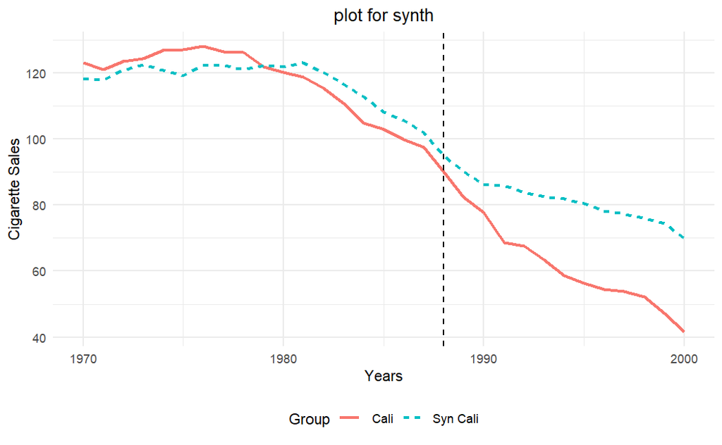

```r
plot_data = data.frame(
  year = rep(unique_years, 2),
  cigsale = c(synth_data$Y1plot, syn),
  group = rep(c(" Cali", "Syn Cali"), each = length(unique_years))
)

# Ploting the results using ggplot2
ggplot(plot_data, aes(x = year, y = cigsale, color = group, linetype = group)) +
  geom_line(size = 1) +
  geom_vline(xintercept = 1988, linetype = "dashed", color = "black") +
  labs(
    title = "plot for synth",
    x = "Years",
    y = "Cigarette Sales",
    color = "Group",
    linetype = "Group"
  ) +
  theme_minimal() +
  theme(
    plot.title = element_text(hjust = 0.5),
    legend.position = "bottom"
  )
```

# 2 Question 2

Estimate and plot treatment effect on the California smoking ban using the `{tidysynth}` package.

```r
synth_results = data %>%
  synthetic_control(outcome = cigsale, unit = state, time = year,
                    i_unit = 3, i_time = 1988, generate_placebos = TRUE) %>%
  #  Setting up the synthetic control framework with the outcome variable (cigsale), unit identifier (state),
  # time identifier (year), treatment unit (California, coded as 3), and treatment time (1988).
  # Also generating placebos for inference.
  generate_predictor(time_window = 1970:1988,
                     ln_income = mean(lnincome, na.rm = TRUE),
                     ret_price = mean(retprice, na.rm = TRUE),
                     youth = mean(age15to24, na.rm = TRUE),
                     beersale = mean(beer, na.rm = TRUE),
                     cigsale = mean(cigsale, na.rm = TRUE)) %>%
  # Generating predictor variables by taking the mean of each predictor over the specified time window (1970-1988).
  # The predictors include ln_income (lnincome), ret_price (retprice), youth (age15to24), beersale (beer), and cigsale (cigsale).
  generate_weights(optimization_window = 1970:1988) %>%
          # Generating the weights for the control units by optimizing over the specified window (1970-1988).
  generate_control()
```

```r
ate = synth_control_results %>%
  filter(time_unit > 1988) %>% # Filter the results to include only the post-treatment years (after 1988).
  mutate(diffs = real_y - synth_y) %>% # Calculating the differences between the actual values (real_y) and synthetic control values (synth_y).

  summarize(ATE = mean(diffs)) %>%  # Computing the average of the differences to get the Average Treatment Effect (ATE).
  pull(ATE) # Extract the ATE value from the summarized data.

print(ate)
```

```
[1] -20.2315
```

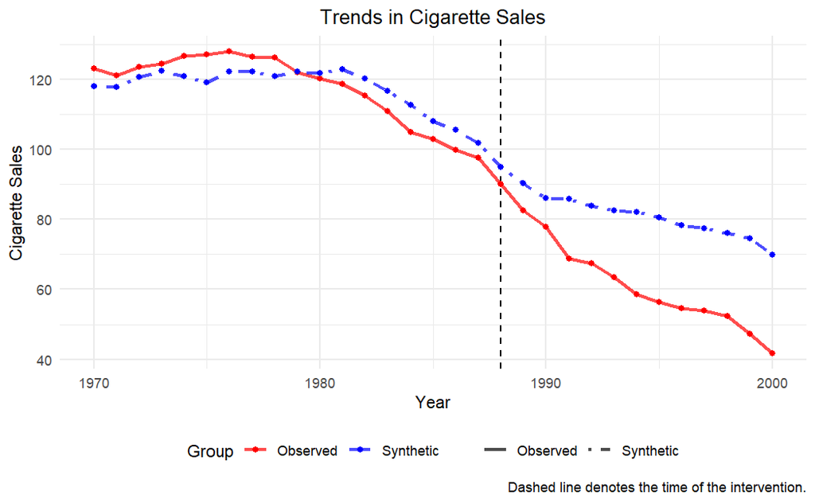

```r
# Plotting the trends in cigarette sales
synth_results %>%
  plot_trends() +
  labs(title = "Trends in Cigarette Sales",
       x = "Year",
       y = "Cigarette Sales",
       color = "Group") +
  scale_color_manual(values = c("Observed" = "red", "Synthetic" = "blue")) +
  theme_minimal() +
  theme(
    plot.title = element_text(hjust = 0.5),
    legend.position = "bottom"
  )
```

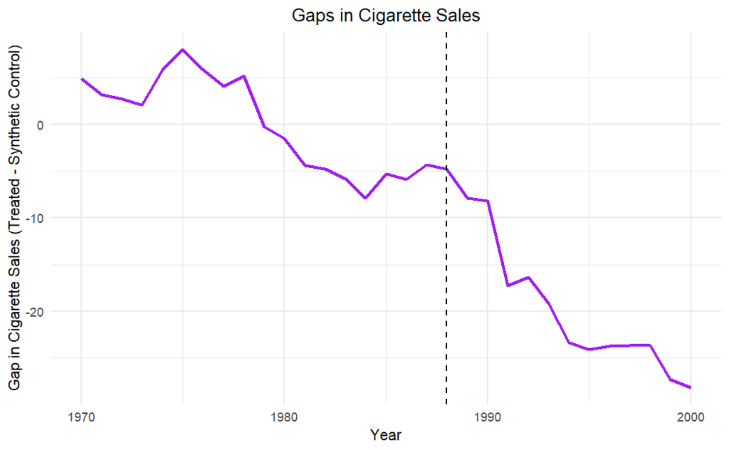

```r
# Creating a dataframe for gaps
gaps_data = synth_control_results %>%
  mutate(gap = real_y - synth_y)

# Plotting the gaps
ggplot(gaps_data, aes(x = time_unit, y = gap)) +
  geom_line(size = 1, color = "purple") +
  geom_vline(xintercept = 1988, linetype = "dashed", color = "black") +
  labs(
    title = "Gaps in Cigarette Sales",
    x = "Year",
    y = "Gap in Cigarette Sales (Treated - Synthetic Control)"
  ) +
  theme_minimal() +
  theme(
    plot.title = element_text(hjust = 0.5)
  )
```

# 3 Question 3

The {Synth} package is used to implement the synthetic control method, where the goal is to create a synthetic control group that mimics the characteristics of the treatment group before the intervention. The synthetic control is constructed as a weighted average of the control units. The {Synth} package is specifically designed for synthetic control analysis, providing robust functions for data preparation and model estimation.

The {tidysynth} package is built on top of the {Synth} package and provides a tidyverse-friendly interface for implementing synthetic control analysis. It leverages the power of the tidyverse ecosystem for data manipulation and visualization. for model estimation, it is Similar to the {Synth} package, but with a more streamlined and tidyverse-compatible approach.

The {tidysynth} package leverages the tidyverse for data manipulation, which can be more intuitive and flexible for users familiar with the tidyverse. The {Synth} package uses a more traditional approach for data preparation. form aspect of Model Implementation both packages ultimately rely on similar underlying methods for creating the synthetic control. However, {tidysynth} provides a more streamlined interface and additional functionality for generating predictors and weights. From visualizatio aspect the {tidysynth} package may offers more sophisticated and customizable plotting options, making it easier to visualize the results in a clear and detailed manner. The {Synth} package’s plotting functions are more basic and may require additional customization. For users comfortable with the tidyverse, the {tidysynth} package offers a more seamless and efficient workflow.

# 4 Question 4

Honestly, it was one of the most informative and valuable classes I have taken at the university. It familiarized me with different libraries in R and, more importantly, provided me with a good understanding of causal inference and how to simulate it. Unfortunately, I was overloaded with many courses this semester and couldn’t keep track of all the classes, but I will have enough time to review all the material again in the summer. This course really showed me how to use machine learning in economics research, especially in the domain of causality. I found this class helpful and informative because you have substantial work experience and know how to transfer this experience to students, familiarizing us with real-world business scenarios. I appreciate your time and teaching and would gladly take any classes you offer next semester. I hope that for the next semester, you can have a whole semester for teaching.